# Data Science Salaries Written Report

Author

Brody Pinto

## Abstract

For this final project, I made a Shiny App to look at job salaries in the field of data science and other related fields. This project is of an exploratory nature, thus there is no one driving research question I aimed to answer. Instead, my goal was to provide an app that allows the user to visualize any trends they may be interested in, giving the user the autonomy to explore the data in any way they choose. This high degree of interactivity, however, makes the process of “data storytelling” nearly impossible. However, in this report, I will highlight three questions of interest with the hopes of providing insight towards the use and interpretation of the app. The case studies presented in this report aim to examine the distribution of pay for data scientists starting their careers, to visualize the increasing trend in data analytics jobs over time, and to emphasize the spread in salaries for engineering positions of different specialties.

## Introduction

The dataset I used in this project is called **Latest Data Science Job Salaries**, published on Kaggle by Sourav Banerjee: https://www.kaggle.com/datasets/iamsouravbanerjee/data-science-salaries-2023. These data encompass job salary data for the field of data science and other related fields through the years 2020 through early 2024. Most of the salary data comes from the United States of America, but also does include data from 74 other countries across the world. This dataset has been instrumental in my understanding of how the field of data science and its associated compensations have changed over recent years.

**Variables of Interest**

- `Salary.in.USD`: job salary converted to USD
- `Job.Title`: job position title
- `Job.Category`: category of job position (added by myself)
- `Experience.Level`: factor of individual’s experience level (Entry, Mid, Senior, Executive)
- `Company.Size`: factor of the company’s size (Small, Medium, Large)
- `Company.Location`: geographic location of the company
- `Employment.Type`: factor of job position type (Full-Time, Part-Time, Freelance)
- `Year`: year of employment (2020-2024)

**Questions of Interest**

1. What is the distribution of salary for Data Scientist Entry- and Mid-level positions?
2. How has the experience level and pay of Data Analysts changed over the course of this dataset (2020 through early 2024)?
3. For the Engineer position, how does the shape of the pay differ for different specialties (AI Engineer vs. Data Science Engineer vs. Machine Learning Engineer)?

## Case Study Visuals

```r
#/ warning: false
#/ output: false
library(tidyverse)

options(scipen = 100)

theme_set(theme_minimal())

salary <- read.csv("data/v7_Latest_Data_Science_Salaries.csv", stringsAsFactors = TRUE) |>
  filter(!is.na(Salary.in.USD))

salary = salary |>
  mutate(Job.Category = case_when(str_detect(Job.Title, pattern = "AI ") == TRUE ~ "Artificial Intelligence",
                                  str_detect(Job.Title, pattern = "Autonomous") == TRUE ~ "Artificial Intelligence",
                                  str_detect(Job.Title, pattern = "Computer Vision") == TRUE ~ "Artificial Intelligence",
                                  str_detect(Job.Title, pattern = "NLP") == TRUE ~ "Artificial Intelligence",
                                  str_detect(Job.Title, pattern = "Prompt Engineer") == TRUE ~ "Artificial Intelligence",
                                  str_detect(Job.Title, pattern = "BI ") == TRUE ~ "Business Intelligence",
                                  str_detect(Job.Title, pattern = "Business") == TRUE ~ "Business Intelligence",
                                  str_detect(Job.Title, pattern = "Data Product") == TRUE ~ "Business Intelligence",
                                  str_detect(Job.Title, pattern = "Financ") == TRUE ~ "Business Intelligence",
                                  str_detect(Job.Title, pattern = "Data Sci") == TRUE ~ "Data Science",
                                  str_detect(Job.Title, pattern = "Data Lead") == TRUE ~ "Data Science",
                                  str_detect(Job.Title, pattern = "Data Manage") == TRUE ~ "Data Science",
                                  str_detect(Job.Title, pattern = "Data Specialist") == TRUE ~ "Data Science",
                                  str_detect(Job.Title, pattern = "Head of Data") == TRUE ~ "Data Science",
                                  str_detect(Job.Title, pattern = "ML") == TRUE ~ "Machine Learning",
                                  str_detect(Job.Title, pattern = "Machine") == TRUE ~ "Machine Learning",
                                  str_detect(Job.Title, pattern = "Deep Learning") == TRUE ~ "Machine Learning",
                                  str_detect(Job.Title, pattern = "Big ") == TRUE ~ "Big Data",
                                  str_detect(Job.Title, pattern = "Cloud") == TRUE ~ "Cloud Data",
                                  str_detect(Job.Title, pattern = "Data Architect") == TRUE ~ "Data Organization",
                                  str_detect(Job.Title, pattern = "Data Engineer") == TRUE ~ "Data Organization",
                                  str_detect(Job.Title, pattern = "Data Developer") == TRUE ~ "Data Organization",
                                  str_detect(Job.Title, pattern = "Data Infrastructure") == TRUE ~ "Data Organization",
                                  str_detect(Job.Title, pattern = "ETL ") == TRUE ~ "Data Organization",
                                  str_detect(Job.Title, pattern = "Data Operations") == TRUE ~ "Data Operations",
                                  str_detect(Job.Title, pattern = "DevOps") == TRUE ~ "Data Operations",
                                  str_detect(Job.Title, pattern = "Data Integration") == TRUE ~ "Data Operations",
                                  str_detect(Job.Title, pattern = "Data Strateg") == TRUE ~ "Data Operations",
                                  str_detect(Job.Title, pattern = "Decision Scientist") == TRUE ~ "Data Operations",
                                  str_detect(Job.Title, pattern = "Data Model") == TRUE ~ "Data Modeling",
                                  str_detect(Job.Title, pattern = "Data Quality") == TRUE ~ "Data Quality",
                                  str_detect(Job.Title, pattern = "Data Vis") == TRUE ~ "Data Visualization",
                                  str_detect(Job.Title, pattern = "Research Analyst") == TRUE ~ "Research",
                                  str_detect(Job.Title, pattern = "Research Engineer") == TRUE ~ "Research",
                                  str_detect(Job.Title, pattern = "Research Scientist") == TRUE ~ "Research",
                                  str_detect(Job.Title, pattern = "Applied Scientist") == TRUE ~ "Research",
                                  str_detect(Job.Title, pattern = "Analy") == TRUE ~ "Data Analytics"
                                  )) |>
  mutate(Company.Location = as.character(Company.Location),
         Employment.Type = as.character(Employment.Type),
         Experience.Level = fct_relevel(Experience.Level, c("Entry", "Mid", "Senior", "Executive")),
         Company.Size = fct_relevel(Company.Size, c("Small", "Medium", "Large")))
```

**1. What is the distribution of salary for Data Scientist Entry- and Mid-level positions?**

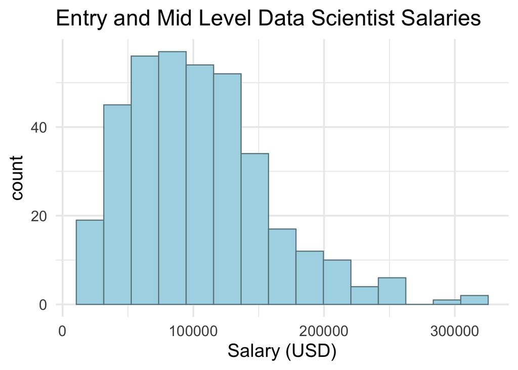

```r
ds_static = salary |>
  filter(Job.Title == "Data Scientist") |>
  filter(Experience.Level %in% c("Entry", "Mid"))
ggplot(data = ds_static, aes(x = Salary.in.USD)) +
      geom_histogram(bins = 15, col = "lightblue4", fill = "lightblue") +
      labs(title = glue::glue("Entry and Mid Level Data Scientist Salaries")) +
      theme_minimal(base_size = 18) +
      labs(x = "Salary (USD)")
```

**2. How has the experience level and pay of Data Analysts changed over the course of this dataset (2020 through early 2024)?**

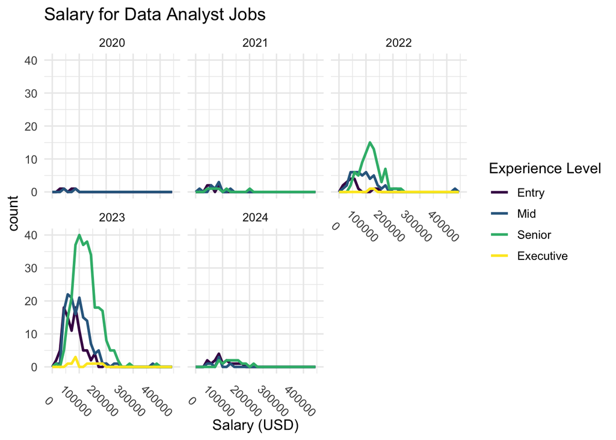

```r
da_static = salary |>
      filter(Job.Title == "Data Analyst")
ggplot(data = da_static, aes(x = Salary.in.USD, color = Experience.Level)) +
      geom_freqpoly(linewidth = 1) +
      facet_wrap(~ Year) +
      labs(title = glue::glue("Salary for Data Analyst Jobs")) +
      theme_minimal(base_size = 12) +
      labs(x = "Salary (USD)", color = "Experience Level") +
      scale_color_viridis_d() +
      theme(axis.text.x = element_text(angle = -45))
```

**3. For the Engineer position, how does the shape of the pay differ for different specialties (AI Engineer vs. Data Science Engineer vs. Machine Learning Engineer)?**

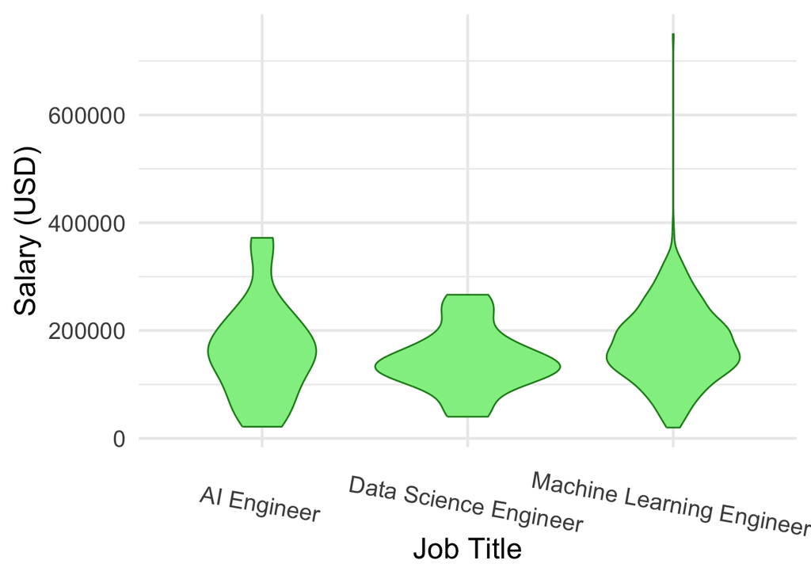

```r
violin_df = salary |>
      filter(Job.Title %in% c("AI Engineer", "Data Science Engineer", "Machine Learning Engineer"))
ggplot(data = violin_df, aes(x = Job.Title, y = Salary.in.USD)) +
      geom_violin(fill = "lightgreen", color = "forestgreen") +
      labs(x = "Job Title", y = "Salary (USD)") +
      theme_minimal(base_size = 18) +
      theme(axis.text.x = element_text(angle = -10))
```